# Problema 5 - Checkpoint 3

Para este checkpoint continuaremos utilizando os dados de encontros relâmpagos e fazendo análise de regressão. Porém, agora estaremos tentando explicar uma variável categórica, em busca dos fatores que têm mais efeito significativo na mesma.

A variável categórica a ser explicada é “dec”, ela é referente a ocorrência de match entre as duas pessoas envolvidas no encontro. Para criação do modelo, foram escolhidas como variáveis independentes algumas principais que descrevem a opinião do participante 1 sobre a pessoa com quem acabou de ter um encontro, foram elas:

- attr - nota para o quão atraente a outra pessoa foi avaliada
- sinc - nota para o quão sincera a outra pessoa foi avaliada
- fun - nota para o quão divertida a outra pessoa foi avaliada
- shar - nota para quanto interesses são compartilhado com a outra pessoa
- like - nota para o quanto a outra pessoa agradou no geral
- prob - nota para quanto se acha que a outra pessoa tem interesse em um reencontro

Inicialmente, uma breve visualização da relação e frequência entre as variáveis utilizadas. Manchas mais escuras representam uma maior ocorrência.

```r
dados = read.csv("speed-dating2.csv")
dados = data.frame(dados$dec, dados$attr, dados$sinc, dados$fun, dados$shar, dados$like, dados$prob)
names(dados) <- c("dec", "attr", "sinc", "fun", "shar", "like", "prob")

head(dados)
```

```
##   dec attr sinc fun shar like prob
## 1 yes    6    9   7    5    7    6
## 2 yes    7    8   8    6    7    5
## 3 yes    5    8   8    7    7   NA
## 4 yes    7    6   7    8    7    6
## 5 yes    5    6   7    6    6    6
## 6  no    4    9   4    4    6    5
```

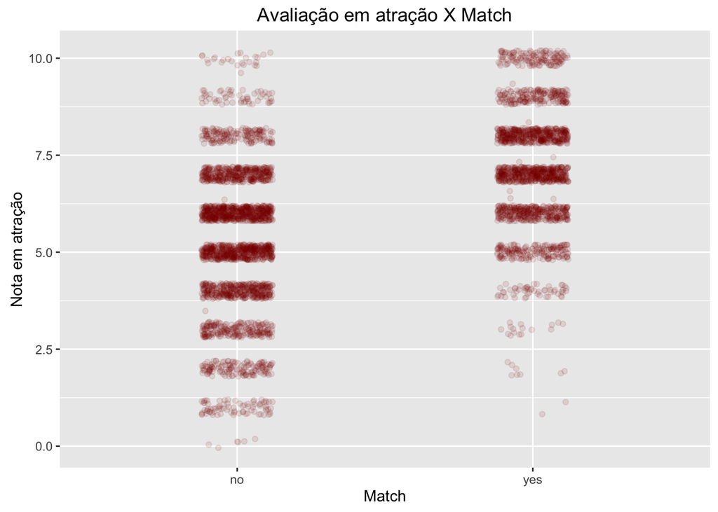

```r
ggplot(dados, aes(dados$dec, dados$attr)) +
  geom_point(alpha = 0.1, position = position_jitter(width = 0.3), color="darkred") +
    labs(title="Avaliação em atração X Match", x= "Match", y="Nota em atração")
```

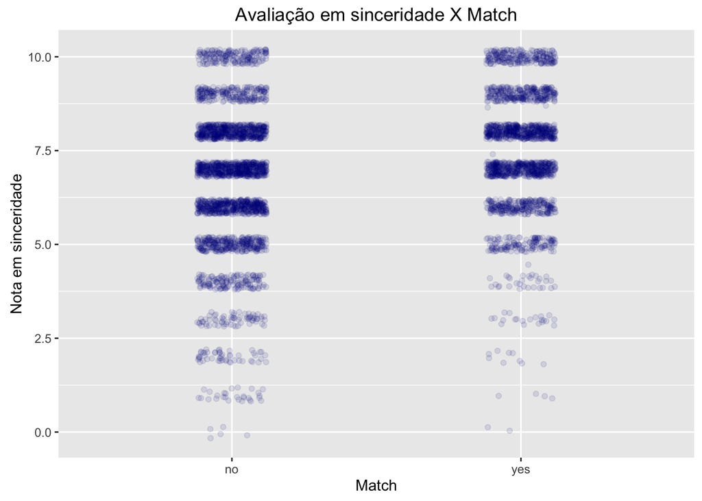

```r
ggplot(dados, aes(dados$dec, dados$sinc)) +
  geom_point(alpha = 0.1, position = position_jitter(width = 0.3), color="darkblue") +
    labs(title="Avaliação em sinceridade X Match", x= "Match", y="Nota em sinceridade")
```

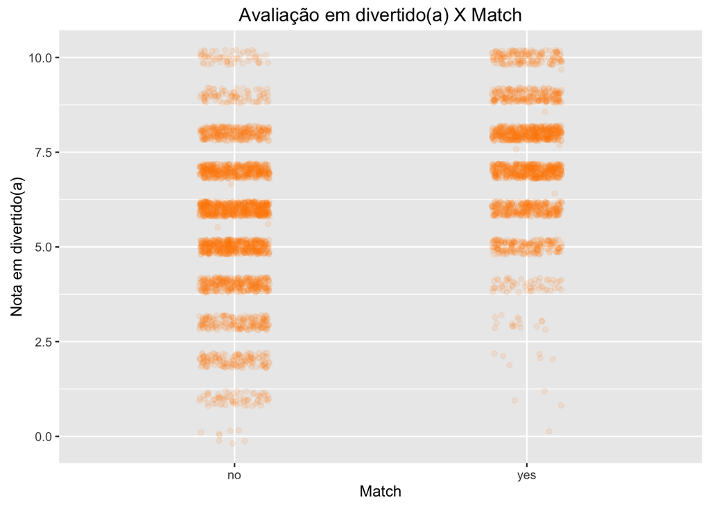

```r
ggplot(dados, aes(dados$dec, dados$fun)) +
  geom_point(alpha = 0.1, position = position_jitter(width = 0.3), color="darkorange") +
    labs(title="Avaliação em divertido(a) X Match", x= "Match", y="Nota em divertido(a)")
```

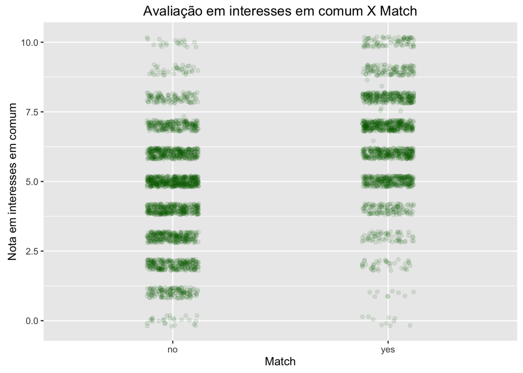

```r
ggplot(dados, aes(dados$dec, dados$shar)) +
  geom_point(alpha = 0.1, position = position_jitter(width = 0.3), color="darkgreen") +
    labs(title="Avaliação em interesses em comum X Match", x= "Match", y="Nota em interesses em comum")
```

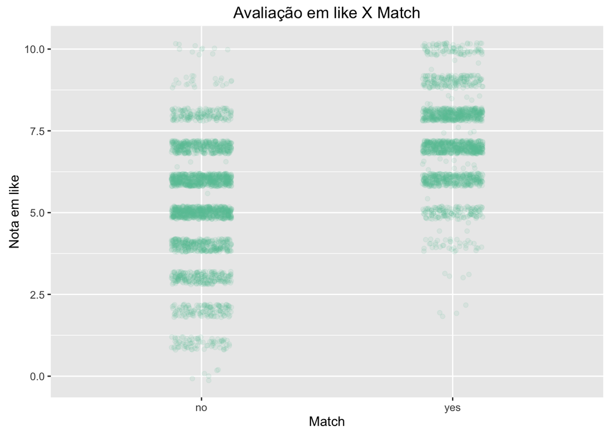

```r
ggplot(dados, aes(dados$dec, dados$like)) +
  geom_point(alpha = 0.1, position = position_jitter(width = 0.3), color="#66c2a4") +
    labs(title="Avaliação em like X Match", x= "Match", y="Nota em like")
```

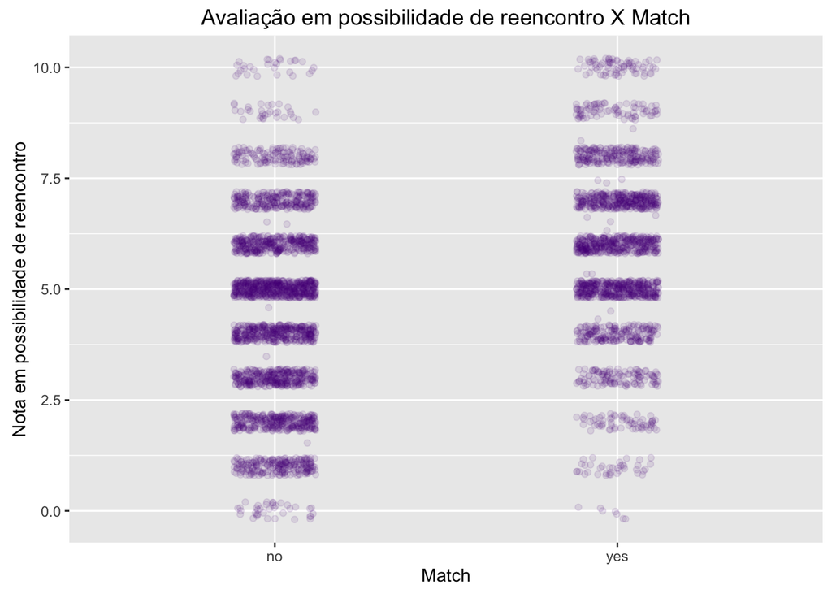

```r
ggplot(dados, aes(dados$dec, dados$prob)) +
  geom_point(alpha = 0.1, position = position_jitter(width = 0.3), color="purple4") +
    labs(title="Avaliação em possibilidade de reencontro X Match", x= "Match", y="Nota em possibilidade de reencontro")
```

Agora montamos o modelo com a variáveis independentes selecionadas com objetivo de descobrir se cada uma delas possui influência significativa e qual a “força” na variável dependente de match.

```r
model <- glm(dec ~ attr + sinc + fun + shar + like + prob, data=dados, family = 'binomial')
```

Como a função glm( ) atribui 0 ao primeiro level da variável categórica e 1 ao segundo level, nosso modelo estará tentado explicar a possibilidade de match ser positiva.

### 1. Que fatores nos dados têm efeito significativo na chance do casal ter um match? E como é esse efeito (positivo/negativo)?

```r
tidy(model, conf.int = TRUE)
```

```
##          term    estimate  std.error  statistic       p.value     conf.low
## 1 (Intercept) -6.60423270 0.25283240 -26.120990 2.105837e-150 -7.107680186
## 2        attr  0.43292914 0.03046307  14.211606  7.762445e-46  0.373651768
## 3        sinc -0.29426748 0.03002783  -9.799826  1.127799e-22 -0.353564392
## 4         fun  0.06752731 0.03134354   2.154425  3.120686e-02  0.006106971
## 5        shar  0.12450887 0.02571736   4.841434  1.289056e-06  0.074188164
## 6        like  0.59056972 0.04195855  14.075076  5.404711e-45  0.509104107
## 7        prob  0.16620984 0.02231472   7.448438  9.445195e-14  0.122592138
##    conf.high
## 1 -6.1163910
## 2  0.4931043
## 3 -0.2358192
## 4  0.1290089
## 5  0.1750330
## 6  0.6736343
## 7  0.2100903
```

A partir do resumo acima, é possível concluir algumas coisas sobre as variáveis:

- Observando os intervalos de confiança de cada variável, é possível dizer que todas posssuem influência significativa já que o valor 0 não está presente em nenhum dos intervalos.
- A única que possui influência de efeito negativo é a variável **sinc**, todas a outras apresentam efeito positivo.
- Apesar de apresentar efeito significativo, esse valor referente a variável **fun** não é muito alto, apenas 0,067.

### 2. Que fatores nos dados têm mais efeito na chance de um casal ter match?

Para saber quais fatores tem mais efeito na chance de um casal ter match, geramos a tabela abaixo, que separa exatamente os valores de interesse para responder essa pergunta.

```r
 stargazer(model, type="text")
```

```
##
## =============================================
##                       Dependent variable:
##                   ---------------------------
##                               dec
## ---------------------------------------------
## attr                       0.433***
##                             (0.030)
##
## sinc                       -0.294***
##                             (0.030)
##
## fun                         0.068**
##                             (0.031)
##
## shar                       0.125***
##                             (0.026)
##
## like                       0.591***
##                             (0.042)
##
## prob                       0.166***
##                             (0.022)
##
## Constant                   -6.604***
##                             (0.253)
##
## ---------------------------------------------
## Observations                 4,207
## Log Likelihood            -1,960.045
## Akaike Inf. Crit.          3,934.091
## =============================================
## Note:             *p<0.1; **p<0.05; ***p<0.01
```

- Vemos que as três principais variáveis de efeito presentes no modelo são **attr**, **sinc** e **like**, pois essas apresentam valores mais próximos de -1 ou 1.
- Dentre a três principais, **like** é a variável independente que tem mais efeito na chance de um casal ter match, sendo esse efeito positivo.